# Visualizing Alignments in IGV

Noelle Wheeler

2023-03-14

My reference genome is hg38, downloaded from the UCSC genome browser.

#### 3. Genomic coordinates of gene ACTB = chr7:5,525,148-5,532,601 for hg38.

#### 4. Use the previous genomic coordinates to filter one of your project BAM alignments to only this region.

```
cd /athena/angsd/scratch/naw4005/alignments/
samtools view -b SRR8367773.Aligned.sortedByCoord.out.bam chr7:5525148-5532601 > SRR8367773.actb.bam
samtools index SRR8367773.actb.bam
```

#### 5. Download both the BAM and BAI files you have generated to your local computer.

```
scp naw4005@aphrodite.med.cornell.edu:/athena/angsd/scratch/naw4005/alignments/SRR8367773.actb.bam Desktop

scp naw4005@aphrodite.med.cornell.edu:/athena/angsd/scratch/naw4005/alignments/SRR8367773.actb.bam.bai Desktop
```

#### 6. Open the BAM file with IGV. You should see coverage peaks as well as alignments.

My data is paired-end so I colored alignments by first of pair strand.

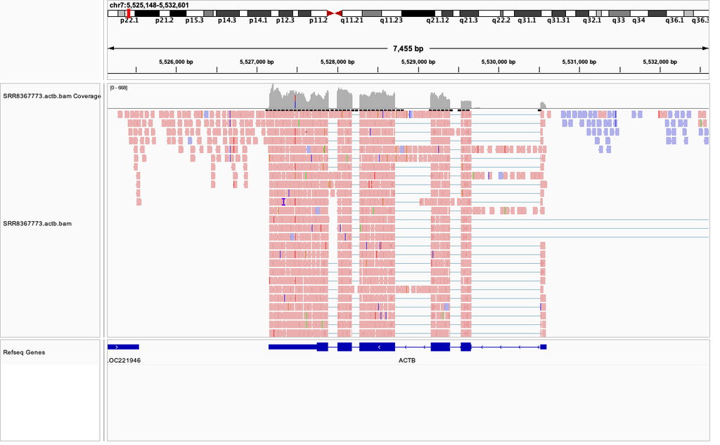

#### 9. Observations about the alignments.

The library appears to be stranded because we can see an unequal amount of forward/reverse stands. There are a fair amount of reads in the introns of this ACTB gene. There is less coverage in the beginning of the gene.

#### 1. Include additional sample

I included sample SRR8368061 which is a BP1 positive patient.

```
samtools view -b SRR8368061.Aligned.sortedByCoord.out.bam chr7:5525148-5532601 > SRR8368061.actb.bam
samtools index SRR8368061.actb.bam
```

```
scp naw4005@aphrodite.med.cornell.edu:/athena/angsd/scratch/naw4005/alignments/SRR8368061.actb.bam Desktop

scp naw4005@aphrodite.med.cornell.edu:/athena/angsd/scratch/naw4005/alignments/SRR8368061.actb.bam.bai Desktop
```

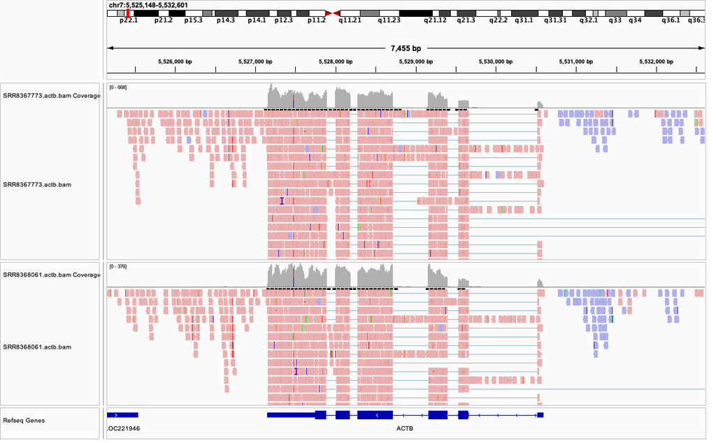

#### 2. Load the GTF you used to generate the STAR index.

I downloaded my own GTF file but was not able to visualize alignments with it.

```
cd /athena/angsd/scratch/naw4005
cat hg38.ensGene.gtf | sort -S4G -k1,1 -k4,4n | bgzip -c > hg38.ensGene.sorted.gtf
tabix hg38.ensGene.sorted.gtf
```

```
scp naw4005@aphrodite.med.cornell.edu:/athena/angsd/scratch/naw4005/hg38.ensGene.sorted.gtf.tbi Desktop

scp naw4005@aphrodite.med.cornell.edu:/athena/angsd/scratch/naw4005/hg38.ensGene.sorted.gtf Desktop
```

Download the files

```
scp naw4005@aphrodite.med.cornell.edu:/athena/angsd/scratch/naw4005/hg38.ensGene.sorted.gtf.gz Desktop

scp naw4005@aphrodite.med.cornell.edu:/athena/angsd/scratch/naw4005/hg38.ensGene.sorted.gtf.gz Desktop
```